# Examples for Bear Workshop 2

Peter F Halpin

## Set up sesssion

```r
devtools::install_github("peterhalpin/BearShare")
library("BearShare")
library("ltm")
library("ggplot2")
library("stats4")
```

## Calibrate NAEP items using 2PL and save item parameters

```r
calib_ltm <- ltm(calibration ~ z1)
beta <- coef(calib_ltm)[,1]
alpha <- coef(calib_ltm)[,2]
```

# The `friends` dataset

Item responses from 7 pairs of friends working on two sets of items. Items names are formatted as follows: first 3 characters are the item number (1:100). The fourth character is the item difficulty, according to NAEP (E = easy, M = medium, H = hard). The fifth character is the item content area, according to NAEP (A = algebra, D = data, G = graphs, M = measurement, N = numbers). The `_I` and `_C` denote whether items were responded to by individuals working alone or in collaboration with their partner, respectively. With the individual and collaborative forms, the items are ordered according to their difficulty in the calibration sample.

```r
head(friends[,c(1:3,26, 30, 37, 50)])
```

[output not shown]

Let’s get the individual and collaborative forms

```r
ind_form <- col_form <- friends[,-1]
ind_form[, grep("C", names(ind_form))] <- NA
col_form[, grep("I", names(col_form))] <- NA
```

Apply the conjunctive scoring rule to the collaborative form

```r
odd <- seq(1, nrow(col_form), by = 2)
col_form[odd,] <- col_form[odd+1,] <- col_form[odd,]*col_form[odd+1,]
```

Estimate and plot abilities on individual and collaborative test forms. Any guesses about which pairs exemplify which models of collaboration??

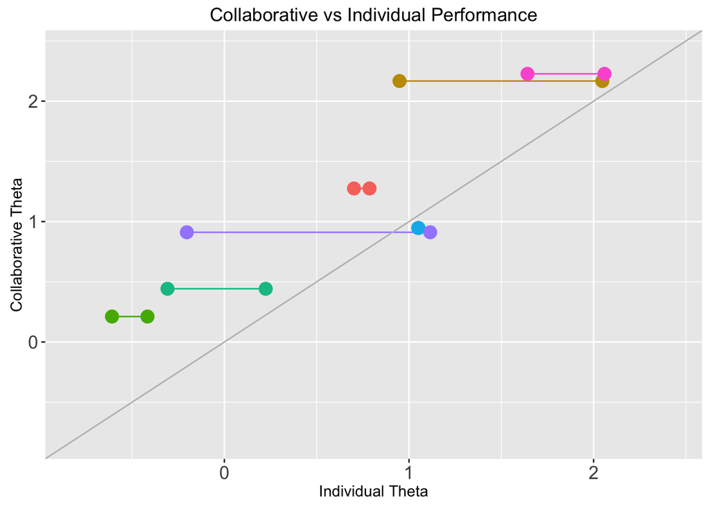

```r
ind_theta <- factor.scores(calib_ltm, ind_form, type = "EB", prior = F)$score.dat$z1
col_theta <- factor.scores(calib_ltm, col_form, type = "EB", prior = F)$score.dat$z1
barbell_plot(ind_theta, col_theta)
```

Set up and run LR tests for models. Note that `nrow(resp)` and `length(col_tehta)` should correspond to the number of pairs; and that `ncol(resp)`, `alpha`, and `beta`should only include items on the collaborative form. Use `help(lr_test)` to see a full list of arguments, or write `lr_test` to see the source code.

Do the conclusions baed on the LR tests line up with the barbell plot? Any other considerations?

```r
parms <- coef(calib_ltm)
beta_C <- parms[grep("C", row.names(parms)), 1]
alpha_C <- parms[grep("C", row.names(parms)), 2]

resp <- col_form[odd, grep("C", names(col_form))]
models <- c("Ind", "Min", "Max", "AI")

lr <- lr_test(resp, models, alpha_C, beta_C, ind_theta, col_theta[odd], n_boot = 500)
```

```
## Running bootstraps for model 1 ...Running bootstraps for model 2 ...Running bootstraps for model 3 ...Running bootstraps for model 4 ...
```

```r
lr
```

```
## $Ind
##          lr  ci_lower ci_upper p_obs
## 1 15.626912 -2.543925 5.511496 0.000
## 2 13.029250 -1.581155 4.855648 0.002
## 3 21.301076 -3.210561 5.459815 0.000
## 4 15.356967 -2.404060 4.368833 0.000
## 5  6.907128 -2.553805 4.717046 0.012
## 6 19.212359 -1.634272 5.020561 0.000
## 7  6.444560 -1.904604 5.709606 0.014
##
## $Min
##            lr     ci_lower ci_upper p_obs
## 1  2.88111032 0.0003687687 4.536300 0.090
## 2  9.15445887 0.0013110706 5.218080 0.006
## 3  5.86997109 0.0010146137 5.600754 0.022
```

[output cut: 24 more lines]

Here is the sanity check from the slides. The basic idea is to use the individual form and apply the conjunctive scoring rule. In this case We know the individual model must be correct – but what does the LR test tell us?

```r
beta_I <- parms[grep("I", row.names(parms)), 1]
alpha_I <- parms[grep("I", row.names(parms)), 2]

sanity_form  <- ind_form[odd,]*ind_form[odd+1,]

sanity_theta <- factor.scores(calib_ltm,
                      sanity_form,
                      type = "EB",
                      prior = F)$score.dat$z1

sanity_resp <- sanity_form[, grep("I", names(sanity_form))]

sanity_lr <- lr_test(sanity_resp,
                    models,
                    alpha_I,
                    beta_I,
                    ind_theta,
                    sanity_theta,
                    n_boot = 500)
```

```
## Running bootstraps for model 1 ...Running bootstraps for model 2 ...Running bootstraps for model 3 ...Running bootstraps for model 4 ...
```

```r
sanity_lr
```

```
## $Ind
##           lr  ci_lower ci_upper p_obs
## 1 -1.4258688 -2.885777 5.185528 0.816
## 2  0.2352626 -1.958687 4.700824 0.528
## 3 -2.2597744 -2.804506 5.123112 0.868
## 4 -0.3505413 -2.660457 5.167014 0.520
## 5 -0.2311175 -2.684492 4.569739 0.616
## 6  1.0350566 -1.968297 4.270270 0.296
## 7  0.6941506 -1.973299 4.761772 0.374
##
## $Min
##           lr     ci_lower ci_upper p_obs
## 1 1.95744815 0.0025427160 5.146305 0.178
## 2 0.00000000 0.0005477851 4.907997 0.996
## 3 0.98088732 0.0017515267 5.035834 0.350
```

[output cut: 24 more lines]

Suggestions for further analyses: Use `sim_data` to generate data from a model (`\help(sim_data)`). Use the `pilot` dataset to run an analysis for some of the data that I’ll talk about this afternoon and tomorrow.